# ICT_LIS_661_Project_3

# Welcome to Project 3!

Before moving on, please make a copy of this file and rename it in a way that makes a clear distinction between the original file and the file you’ll eventually submit.

> Under the headers below, I’ll provide you with certain instructions, all of them formatted as blockquotes, like this paragraph is. Under each set of instructions, leave a blank line and then type your (non-blockquoted) response on the line after the blank one. At the very end of this document, I’ll provide instructions for *knitting* and submitting the `.Rmd` to Canvas.

## Project 3, Part 1: Your Dataset [1 point]

> For this project, you will need to identify a dataset with at least 100 observations and 5 variables (at least 3 of which are quantitative). A dataset with at least 1,000 observations and 10 variables would be even better—but not necessary. This does not need to be a publicly available dataset, but please ensure that you can use the dataset legally and ethically. Store the data somewhere in your GitHub repository for this class.

> It is fine for this to be a dataset that you have used previously in this class; in fact, *Part 1* of this project repeats much of Project 2. There’s real value in repeating that experience on new data, but I also won’t blame you for saving yourself some time and copying over text and code from Project 2. However, if you are reusing a dataset, you must make sure that the dataset is appropriate for performing the analyses I am asking you to do here!

> In the code chunk below, please load the dataset into this document. (Keep in mind that you can—and may need to—load packages as part of this or any other code chunk; however, please do not try to install any packages here). [.5 points]

```r
Salary_Data <- read.csv("Salary_Data.csv", check.names = FALSE)

head(Salary_Data)
```

```
##   Age Gender   Education Level         Job Title Years of Experience Salary
## 1  32   Male Bachelor's Degree Software Engineer                   5  90000
## 2  28 Female   Master's Degree      Data Analyst                   3  65000
## 3  45   Male               PhD    Senior Manager                  15 150000
## 4  36 Female Bachelor's Degree   Sales Associate                   7  60000
## 5  52   Male   Master's Degree          Director                  20 200000
## 6  29   Male Bachelor's Degree Marketing Analyst                   2  55000
```

## Project 3, Part 2: Exploratory Data Analysis [3 points]

> In Modules 9 and 10, we emphasized that it is important to explore our data before we proceed to analysis. For this part of the project, you will therefore carry out some exploratory data analysis.

### Examine Raw Data

> In the code chunk below, run some code for examining (some of) the raw data in your dataset. [1 point]

```r
summary_salary <- Salary_Data |>
group_by(`Education Level`, Gender) |>
summarize(
  mean_salary   = round(mean(Salary, na.rm = TRUE), 2),
  median_salary = round(median(Salary, na.rm = TRUE), 2),
  n             = n(),
  .groups = "drop"
)
summary_salary
```

```
## # A tibble: 12 × 5
##    `Education Level`   Gender   mean_salary median_salary     n
##    <chr>               <chr>          <dbl>         <dbl> <int>
##  1 ""                  ""              NaN            NA      2
##  2 ""                  "Male"       100000        100000      1
##  3 "Bachelor's Degree" "Female"      89165.        75000   1199
##  4 "Bachelor's Degree" "Male"        98972.        85000   1824
##  5 "High School"       "Female"      30756.        26000    251
##  6 "High School"       "Male"        39381.        35000    185
##  7 "High School"       "Other"      119949.       131190.    12
##  8 "Master's Degree"   "Female"     122695.       120000   1068
##  9 "Master's Degree"   "Male"       140061.       140000    791
## 10 "Master's Degree"   "Other"      161393        161393      2
## 11 "PhD"               "Female"     160266.       165000    496
## 12 "PhD"               "Male"       168711.       180000    873
```

### Summarize Data

> In the code chunk below, run some code for calculating summary statistics for your dataset. [1 point]

```r
summary_salary <- Salary_Data |>
group_by(`Education Level`, Gender) |>
summarize(
  mean_salary   = round(mean(Salary, na.rm = TRUE), 2),
  median_salary = round(median(Salary, na.rm = TRUE), 2),
  sd_salary     = round(sd(Salary, na.rm = TRUE), 2),
  min_salary    = min(Salary, na.rm = TRUE),
  max_salary    = max(Salary, na.rm = TRUE),
  n             = n(),
  .groups = "drop"
)
summary_salary
```

```
## # A tibble: 12 × 8
##    `Education Level`   Gender   mean_salary median_salary sd_salary min_salary
##    <chr>               <chr>          <dbl>         <dbl>     <dbl>      <dbl>
##  1 ""                  ""              NaN            NA        NA         Inf
##  2 ""                  "Male"       100000        100000        NA      100000
##  3 "Bachelor's Degree" "Female"      89165.        75000     45622.        500
##  4 "Bachelor's Degree" "Male"        98972.        85000     42624.        350
##  5 "High School"       "Female"      30756.        26000     13295.      25000
##  6 "High School"       "Male"        39381.        35000     19115.      25000
##  7 "High School"       "Other"      119949.       131190.    45228.      62852
##  8 "Master's Degree"   "Female"     122695.       120000     41693.      32000
##  9 "Master's Degree"   "Male"       140061.       140000     36942.      40000
## 10 "Master's Degree"   "Other"      161393        161393         0      161393
## 11 "PhD"               "Female"     160266.       165000     30951.      55000
## 12 "PhD"               "Male"       168711.       180000     35781.        579
## # ℹ 2 more variables: max_salary <dbl>, n <int>
```

### Visualize Data

> In the code chunk below, run some code for carrying out an appropriate visualization for at least one key variable in your dataset. [1 point]

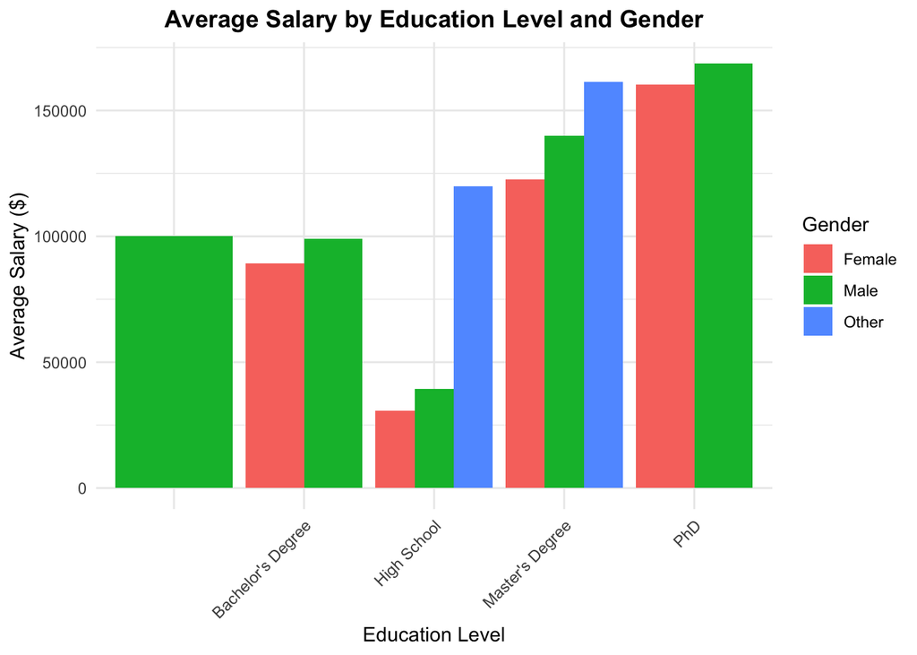

```r
plot_data <- summary_salary |>
filter(!is.na(mean_salary))

ggplot(plot_data, aes(x = `Education Level`, y = mean_salary, fill = Gender)) +
  geom_col(position = "dodge") +
  labs(
 title = "Average Salary by Education Level and Gender",
    x = "Education Level",
    y = "Average Salary ($)"
  ) +
  theme_minimal() +
  theme(
  plot.title = element_text(hjust = 0.5, face = "bold"),
 axis.text.x = element_text(angle = 45, hjust = 1)
  )
```